# Project - AllLife Bank Customer Segmentation

## Context:

- AllLife Bank wants to focus on its credit card customer base in the next financial year. They have been advised by their marketing research team, that the penetration in the market can be improved.
- Based on this input, the Marketing team proposes to run personalized campaigns to target new customers as well as upsell to existing customers. Another insight from the market research was that the customers perceive the support services of the back poorly.
- Based on this, the Operations team wants to upgrade the service delivery model, to ensure that customer queries are resolved faster. Head of Marketing and Head of Delivery both decide to reach out to the Data Science team for help.

## Objective:

- The objective of this project is to identify different segments in the existing customer, based on their spending patterns as well as past interaction with the bank, using clustering algorithms, and provide recommendations to the bank on how to better market to and service these customers.
- Following are the Key questions to be solved:
  1. Identify the different segments in the existing customer base
  2. Identify opportunities to better the services to the Customer
  3. Identify opportunities to expand the Cardit card customer base

## Data Information

- The data provided is of various customers of a bank and their financial attributes like credit limit, the total number of credit cards the customer has, and different channels through which customers have contacted the bank for any queries (including visiting the bank, online and through a call center).
- The detailed data dictionary is given below:

**Customer Details**

- Sl_No: Primary key of the records
- Customer Key: Customer identification number
- Average Credit Limit: Average credit limit of each customer for all credit cards
- Total credit cards: Total number of credit cards possessed by the customer
- Total visits bank: Total number of visits that customer made (yearly) personally to the bank
- Total visits online: Total number of visits or online logins made by the customer (yearly)
- Total calls made: Total number of calls made by the customer to the bank or its customer service department (yearly)

## Table of Contents (TOC)

##### - *Importing Packages*

##### - *Unwrapping Customer Information*

- *Data Description*

##### - *Data Pre-Processing & Sanity Checks*

##### - *Summary of Data Analysis*

##### - *EDA Analysis*

- *Insights from Data*
- *Univariate Analysis*
  - Summary provided under each feature chart
- *Bivariate Analysis*
  - *Data Summary*
- *Multivariate Analysis*

##### - *Clustering Techniques*

- *Data preparation for Modeling*
- *Feature Scaling*

##### - *Cluster Analysis - Applying K-means Algorithm*

- *Using Silhouette Visualizations*
- *Applying KMeans Algorithm - For Selected Cluster*
- *Cluster Profiling*
- *Insights*

##### - *Cluster Analysis - Applying Hierarchical Cluster Algorithm*

- *Cophenetic Correlation Analysis*
- *Using Dendogram Visualizations across Metrics/Linkage*
- *Applying Hierarchical Clustering - Euclidean with Ward linkage*
- *Cluster Profiling*
- *Insights*

##### - *Summary - Comparing K-Means & Hierarchical Cluster Techniques*

##### - *Insights & Recommendations*

##### - *PCA Visualization*

```
- (For study pruposes only)
```

## Importing required Packages:

*Click to return to TOC*

```python
# Importing the Python Libraries to help with reading and manipulating data
import numpy as np
import pandas as pd
from IPython.display import Image

# Importing libraries to help with data visualization
import matplotlib.pyplot as plt
import seaborn as sns
from matplotlib.ticker import PercentFormatter

# Used for Ignore warnings. When we generate the output, then we can use this ignore warning
import warnings
warnings.filterwarnings("ignore")

# Command to tell Python to actually display the graphs
%matplotlib inline

# let's start by installing plotly
!pip install plotly

# importing plotly
import plotly.express as px


# to scale the data using z-score
from sklearn.preprocessing import StandardScaler

# to compute distances
from scipy.spatial.distance import pdist

# to compute distances
from scipy.spatial.distance import cdist

# to perform k-means clustering and compute silhouette scores
from sklearn.cluster import KMeans
from sklearn.metrics import silhouette_score

# to visualize the elbow curve and silhouette scores
from yellowbrick.cluster import KElbowVisualizer, SilhouetteVisualizer

# to perform hierarchical clustering, compute cophenetic correlation, and create dendrograms
from sklearn.cluster import AgglomerativeClustering
from scipy.cluster.hierarchy import dendrogram, linkage, cophenet

# importing library
from sklearn.decomposition import PCA
```

```python
# Loading Used Cars Dataset
df = pd.read_excel("../Dataset/CreditCardCustomerData.xlsx")

# same random results every time
np.random.seed(1)
df.sample(n = 10)

# To copy the data to another object
custData = df.copy()
```

## Unwrapping the Customer Information:

*Click to return to TOC*

```python
df.info()
```

```
<class 'pandas.core.frame.DataFrame'>
RangeIndex: 660 entries, 0 to 659
Data columns (total 7 columns):
 #   Column               Non-Null Count  Dtype
---  ------               --------------  -----
 0   Sl_No                660 non-null    int64
 1   Customer Key         660 non-null    int64
 2   Avg_Credit_Limit     660 non-null    int64
 3   Total_Credit_Cards   660 non-null    int64
 4   Total_visits_bank    660 non-null    int64
 5   Total_visits_online  660 non-null    int64
 6   Total_calls_made     660 non-null    int64
dtypes: int64(7)
memory usage: 36.2 KB
```

```python
# Command to understand the total number of data collected
print(
    f"- There are {df.shape[0]} row samples and {df.shape[1]} attributes of the customer information collected in this dataset."
)
```

```
- There are 660 row samples and 7 attributes of the customer information collected in this dataset.
```

```python
df.head(5)  # Displaying the fist 10 rows of the Dataset
```

|  | Sl_No | Customer Key | Avg_Credit_Limit | Total_Credit_Cards | Total_visits_bank | Total_visits_online | Total_calls_made |
| --- | --- | --- | --- | --- | --- | --- | --- |
| 0 | 1 | 87073 | 100000 | 2 | 1 | 1 | 0 |
| 1 | 2 | 38414 | 50000 | 3 | 0 | 10 | 9 |
| 2 | 3 | 17341 | 50000 | 7 | 1 | 3 | 4 |
| 3 | 4 | 40496 | 30000 | 5 | 1 | 1 | 4 |
| 4 | 5 | 47437 | 100000 | 6 | 0 | 12 | 3 |

```python
df.tail(5)  # Displaying the last 10 rows of the Dataset
```

|  | Sl_No | Customer Key | Avg_Credit_Limit | Total_Credit_Cards | Total_visits_bank | Total_visits_online | Total_calls_made |
| --- | --- | --- | --- | --- | --- | --- | --- |
| 655 | 656 | 51108 | 99000 | 10 | 1 | 10 | 0 |
| 656 | 657 | 60732 | 84000 | 10 | 1 | 13 | 2 |
| 657 | 658 | 53834 | 145000 | 8 | 1 | 9 | 1 |
| 658 | 659 | 80655 | 172000 | 10 | 1 | 15 | 0 |
| 659 | 660 | 80150 | 167000 | 9 | 0 | 12 | 2 |

```python
df.describe(include="all").T
```

|  | count | mean | std | min | 25% | 50% | 75% | max |
| --- | --- | --- | --- | --- | --- | --- | --- | --- |
| Sl_No | 660.0 | 330.500000 | 190.669872 | 1.0 | 165.75 | 330.5 | 495.25 | 660.0 |
| Customer Key | 660.0 | 55141.443939 | 25627.772200 | 11265.0 | 33825.25 | 53874.5 | 77202.50 | 99843.0 |
| Avg_Credit_Limit | 660.0 | 34574.242424 | 37625.487804 | 3000.0 | 10000.00 | 18000.0 | 48000.00 | 200000.0 |
| Total_Credit_Cards | 660.0 | 4.706061 | 2.167835 | 1.0 | 3.00 | 5.0 | 6.00 | 10.0 |
| Total_visits_bank | 660.0 | 2.403030 | 1.631813 | 0.0 | 1.00 | 2.0 | 4.00 | 5.0 |
| Total_visits_online | 660.0 | 2.606061 | 2.935724 | 0.0 | 1.00 | 2.0 | 4.00 | 15.0 |
| Total_calls_made | 660.0 | 3.583333 | 2.865317 | 0.0 | 1.00 | 3.0 | 5.00 | 10.0 |

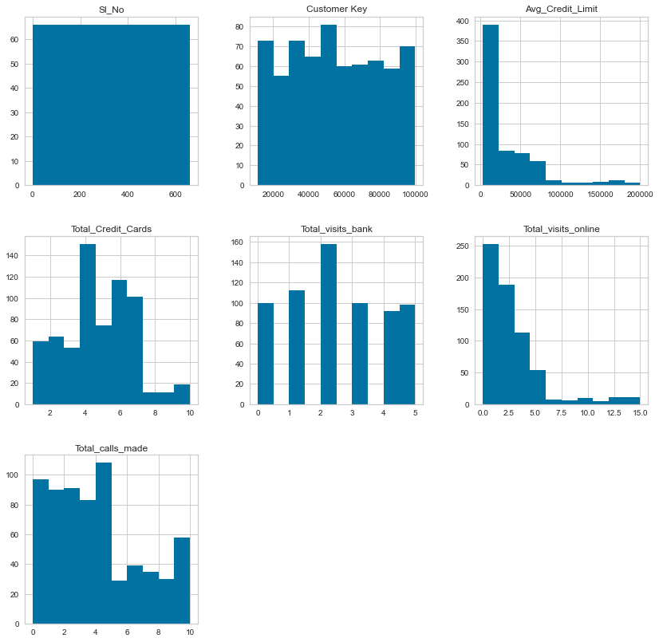

```python
# creating histograms
df.hist(figsize=(14, 14))
plt.show()
```

**Data Description:** *Click to return to TOC*

- `Sl_No` & `Customer_Key` - There are 660 samples of customer data that has been provided in the dataset.
- `Avg_Credit_Limit` - The average credit limit of each customer ranges from a min. of 3,000 to max. of 200,000 with an average mean of 34,574. 50% of the customers are having credit limit in the range of 18,000.
- `Total_Credit_Cards` - The number of credit cards held by the customers are in the range of 1 to 10, with 50% of the customers having at least 5 cards
- `Total_visits_bank` - The number of visits to the bank by the customers are in the range of 0 to 5, with 50% of the customers visiting the bank is at least 2 times
- `Total_visits_online` - The number of online visits by the customers are in the range of 0 to 15, with 50% of the customers perfoming online logins is at least 2 times
- `Total_calls_made` - The number of calls made by the customer to the bank or its customer service department (yearly) are in the range of 0 to 10, with 50% of the customers making calls at least 3 times

## Data Preprocessing & Sanity Checks

*Click to return to TOC*

```python
df.nunique()
```

```
Sl_No                  660
Customer Key           655
Avg_Credit_Limit       110
Total_Credit_Cards      10
Total_visits_bank        6
Total_visits_online     16
Total_calls_made        11
dtype: int64
```

**Observations:**

- We can drop the column - `Sl_No` as it is unique for each customer and will not add value to the model
- The `Customer Key` has less number of entries, possibly there are few repeated Customer information

#### Dropping the Customer ID Column

```python
# Dropping the 'Sl. No' columns since its not required
df.drop(["Sl_No"], axis=1, inplace=True)
```

#### Validating the Customer Key Column

```python
df["Customer Key"].value_counts().head(10)
```

```
97935    2
50706    2
47437    2
37252    2
96929    2
60851    1
58019    1
87219    1
36839    1
12663    1
Name: Customer Key, dtype: int64
```

```python
df[(df["Customer Key"] == 97935) | (df["Customer Key"] == 50706)
   | (df["Customer Key"] == 47437) | (df["Customer Key"] == 37252)
   | (df["Customer Key"] == 96929)].sort_values(by=['Customer Key'], ascending=False, inplace=False)
```

|  | Customer Key | Avg_Credit_Limit | Total_Credit_Cards | Total_visits_bank | Total_visits_online | Total_calls_made |
| --- | --- | --- | --- | --- | --- | --- |
| 104 | 97935 | 17000 | 2 | 1 | 2 | 10 |
| 632 | 97935 | 187000 | 7 | 1 | 7 | 0 |
| 391 | 96929 | 13000 | 4 | 5 | 0 | 0 |
| 398 | 96929 | 67000 | 6 | 2 | 2 | 2 |
| 411 | 50706 | 44000 | 4 | 5 | 0 | 2 |
| 541 | 50706 | 60000 | 7 | 5 | 2 | 2 |
| 4 | 47437 | 100000 | 6 | 0 | 12 | 3 |
| 332 | 47437 | 17000 | 7 | 3 | 1 | 0 |
| 48 | 37252 | 6000 | 4 | 0 | 2 | 8 |
| 432 | 37252 | 59000 | 6 | 2 | 1 | 2 |

- The duplicate values might have occured due to customer profile changes. Though the key has not changed, these could be actual occurences at some point of time. We will retain these rows

```python
df1 = df.groupby(['Avg_Credit_Limit', 'Total_Credit_Cards', 'Total_visits_bank',
            'Total_visits_online', 'Total_calls_made'])[['Customer Key']].count()
```

```python
df1.sort_values(by=['Customer Key'], ascending=False, inplace=False).head(20)
```

| Avg_Credit_Limit | Total_Credit_Cards | Total_visits_bank | Total_visits_online | Total_calls_made | Customer Key |
| --- | --- | --- | --- | --- | --- |
| 18000 | 6 | 3 | 1 | 4 | 2 |
| 47000 | 6 | 2 | 0 | 4 | 2 |
| 12000 | 6 | 5 | 2 | 1 | 2 |
| 8000 | 7 | 4 | 2 | 0 | 2 |
| 6000 | 1 | 0 | 2 | 5 | 2 |
| 52000 | 4 | 2 | 1 | 2 | 2 |
| 5000 | 4 | 5 | 0 | 1 | 2 |
| 10000 | 6 | 4 | 2 | 3 | 2 |
| 9000 | 4 | 5 | 0 | 4 | 2 |
| 8000 | 2 | 0 | 3 | 4 | 2 |
|  | 4 | 0 | 4 | 7 | 2 |
| 34000 | 6 | 5 | 1 | 0 | 1 |
| 38000 | 4 | 3 | 0 | 0 | 1 |
| 37000 | 5 | 5 | 1 | 4 | 1 |
| 34000 | 4 | 3 | 0 | 1 | 1 |
| 37000 | 7 | 2 | 1 | 1 | 1 |
|  |  | 4 | 0 | 1 | 1 |
|  |  | 5 | 0 | 1 | 1 |
| 38000 | 4 | 3 | 1 | 4 | 1 |
| 37000 | 4 | 4 | 2 | 2 | 1 |

```python
# Dropping the 'Customer Key' columns since its not required
df.drop(["Customer Key"], axis=1, inplace=True)
```

#### Checking for Duplicates

```python
# Checking for duplicated rows in the dataset
duplicateSum = df.duplicated().sum()
print("**Inferences:**")
if duplicateSum > 0:
    print(f"- There are {str(duplicateSum)} duplicated row(s) in the dataset")
    # Removing the duplicated rows in the dataset
    df.drop_duplicates(inplace=True)
    print(
        f"- There are {str(df.duplicated().sum())} duplicated row(s) in the dataset post cleaning"
    )
    df.duplicated().sum()
    # resetting the index of data frame since some rows will be removed
    df.reset_index(drop=True, inplace=True)
else:
    print("- There are no duplicated row(s) in the dataset")
```

```
**Inferences:**
- There are 11 duplicated row(s) in the dataset
- There are 0 duplicated row(s) in the dataset post cleaning
```

#### Checking for Columns with missing values

```python
df.isnull().sum()
```

```
Avg_Credit_Limit       0
Total_Credit_Cards     0
Total_visits_bank      0
Total_visits_online    0
Total_calls_made       0
dtype: int64
```

**Observations:**

- There are no missing values

#### Validating the values of the columns to observe the pattern and data correctness

```python
df.describe(include="all").T
```

|  | count | mean | std | min | 25% | 50% | 75% | max |
| --- | --- | --- | --- | --- | --- | --- | --- | --- |
| Avg_Credit_Limit | 649.0 | 34878.274268 | 37813.736638 | 3000.0 | 11000.0 | 18000.0 | 49000.0 | 200000.0 |
| Total_Credit_Cards | 649.0 | 4.708783 | 2.173763 | 1.0 | 3.0 | 5.0 | 6.0 | 10.0 |
| Total_visits_bank | 649.0 | 2.397535 | 1.625148 | 0.0 | 1.0 | 2.0 | 4.0 | 5.0 |
| Total_visits_online | 649.0 | 2.624037 | 2.952888 | 0.0 | 1.0 | 2.0 | 4.0 | 15.0 |
| Total_calls_made | 649.0 | 3.590139 | 2.877911 | 0.0 | 1.0 | 3.0 | 5.0 | 10.0 |

```python
# printing the number of occurrences of each unique value in each categorical column
num_to_display = 10
for column in df.describe(include="all").columns:
    val_counts = df[column].value_counts(
        dropna=False
    )  # Kept dropNA to False to see the NA value count as well
    print("Unique values in", column, "are :")
    print(val_counts.iloc[:num_to_display])
    if len(val_counts) > num_to_display:
        print(f"Only displaying first {num_to_display} of {len(val_counts)} values.")

    print("-" * 50)
    print(" ")
```

```
Unique values in Avg_Credit_Limit are :
8000     32
6000     30
13000    28
9000     27
19000    26
10000    25
11000    24
7000     24
14000    23
17000    23
Name: Avg_Credit_Limit, dtype: int64
Only displaying first 10 of 110 values.
--------------------------------------------------

Unique values in Total_Credit_Cards are :
4     147
6     113
7     100
5      74
2      63
1      58
3      53
10     19
9      11
8      11
Name: Total_Credit_Cards, dtype: int64
--------------------------------------------------

Unique values in Total_visits_bank are :
2    156
1    112
3     99
0     97
5     95
4     90
Name: Total_visits_bank, dtype: int64
--------------------------------------------------

Unique values in Total_visits_online are :
```

[output cut: 13 more lines]

```

Unique values in Total_calls_made are :
4    104
0     96
2     90
1     88
3     82
6     39
7     34
9     32
8     30
5     28
Name: Total_calls_made, dtype: int64
Only displaying first 10 of 11 values.
--------------------------------------------------
```

**Observations:**

*Click to return to TOC*

Post the preprocessing & cleanup, we see:

- `Avg_Credit_Limit` - The credit limit seems to be distributed with avg. limit varying at all levels
- `Total_Credit_Cards` - The number of credit cards held by the customers are in the range of 1 to 10. Most of the Customers have 4 credit cards, followed by customers with 6 & 7 credit cards
- `Total_visits_bank` - The number of visits to the bank by the customers are in the range of 0 to 5. Most of the Customers have visited 2 times, followed by 1 time. There are also customers who have not visited even once to the bank
- `Total_visits_online` - The number of online visits by the customers are in the range of 0 to 15. Most of the Customers have visited 2 times. There are also customers who have not done online logins even once and this category seems to be second highest
- `Total_calls_made` - The number of calls made by the customer to the bank or its customer service department (yearly) are in the range of 0 to 10. Most of the Customers have made 4 calls in a year. There are also customers who have not made any calls even once and this category seems to be second highest

```python
# Observing the data dictionery after the changes
df.info()
```

```
<class 'pandas.core.frame.DataFrame'>
RangeIndex: 649 entries, 0 to 648
Data columns (total 5 columns):
 #   Column               Non-Null Count  Dtype
---  ------               --------------  -----
 0   Avg_Credit_Limit     649 non-null    int64
 1   Total_Credit_Cards   649 non-null    int64
 2   Total_visits_bank    649 non-null    int64
 3   Total_visits_online  649 non-null    int64
 4   Total_calls_made     649 non-null    int64
dtypes: int64(5)
memory usage: 25.5 KB
```

```python
# Command to understand the total number of data collected
print(
    f"- There are {df.shape[0]} row samples and {df.shape[1]} attributes of the customer information collected in this dataset."
)
```

```
- There are 649 row samples and 5 attributes of the customer information collected in this dataset.
```

```python
num_col = df.select_dtypes(include=np.number).columns.tolist()
num_col
```

```
['Avg_Credit_Limit',
 'Total_Credit_Cards',
 'Total_visits_bank',
 'Total_visits_online',
 'Total_calls_made']
```

### Summary of Data Analysis

*Click to return to TOC*

**Data Structure:**

- The Dataset contains 660 rows of Customer information and 7 attributes of data
- All the columns were of int64(7) category in the dataset

**Data Cleaning:**

- `Sl. No` attribute is not required and the column was dropped
- `Customer Key` has few repeated Customers which probably was due to changes in the Customer information. Considering the information would be required information, these duplicates Customer information were not dropped
- `Customer Key` attribute is not required and the column was dropped
- There are no missing values and the data were of proper values which doesnt require any formatting
- Post dropping the above mentioned columns, there were 11 duplicates rows of information which was dropped
- Post cleanup, there were 649 row samples and 5 feature attributes of the customer information retained.

**Data Description:**

- The Customer's average credit limit seems to be distributed and ranges from a min. of 3,000 to max. of 200,000 with an average mean of 34,574. 50% of the customers are having credit limit in the range of 18,000
- Most of the Customers have atleast 4 credit cards, followed by customers with 6 & 7 credit cards
- Customers have visited the banks at least 2 times, ranging between 0-5. There are also customers who have not visited even once to the bank
- Similarly, Customers have visited online system at least 2 times, ranging between 0-15 times. There are also customers who have not visited the online portal even once
- The number of calls made by the customer to the bank or its customer service department (yearly) are in the range of 0 to 10.
- Most of the Customers have atleast made 4 calls in a year. There are also customers who have not made any calls even once and this category seems to be second highest

**For more details, *Click here for Data descriptions* & *Click here for Feature Value observations***

### Common Functions

```python
# function to create labeled barplots


def labeled_barplot(data, feature, perc=False, n=None, hueCol=None):
    """
    Barplot with percentage at the top

    data: dataframe
    feature: dataframe column
    perc: whether to display percentages instead of count (default is False)
    n: displays the top n category levels (default is None, i.e., display all levels)
    """

    total = len(data[feature])  # length of the column
    count = data[feature].nunique()
    if n is None:
        plt.figure(figsize=(count + 1, 5))
    else:
        plt.figure(figsize=(n + 1, 7))

    plt.xticks(rotation=90, fontsize=15)

    ax = sns.countplot(
        data=data,
        x=feature,
        palette="Paired",
        hue=hueCol,
        order=data[feature].value_counts().index[:n].sort_values(),
    )

    for p in ax.patches:
        if perc == True:
            label = "{:.1f}%".format(
                100 * p.get_height() / total
            )  # percentage of each class of the category
        else:
            label = p.get_height()  # count of each level of the category

        x = p.get_x() + p.get_width() / 2  # width of the plot
        y = p.get_height()  # height of the plot

        ax.annotate(
            label,
            (x, y),
            ha="center",
            va="center",
            size=12,
            xytext=(0, 5),
            textcoords="offset points",
        )
        # annotate the percentage

    plt.show()  # show the plot
```

```python
def stacked_barplot(data, predictor, target):
    """
    Print the category counts and plot a stacked bar chart

    data: dataframe
    predictor: independent variable
    target: target variable
    """
    count = data[predictor].nunique()
    sorter = data[target].value_counts().index[-1]
    tab1 = pd.crosstab(data[predictor], data[target], margins=True,).sort_values(
        by=sorter, ascending=False
    )
    print("-" * 30, " Volume ", "-" * 30)
    print(tab1)

    tab1 = pd.crosstab(
        data[predictor], data[target], margins=True, normalize="index"
    ).sort_values(by=sorter, ascending=False)
    print("-" * 30, " Percentage % ", "-" * 30)
    print(tab1)
    print("-" * 120)
    tab = pd.crosstab(data[predictor], data[target], normalize="index").sort_values(
        by=sorter, ascending=False
    )
    tab.plot(kind="bar", stacked=True, figsize=(count + 5, 5))
    plt.legend(
        loc="lower left", frameon=False,
    )
    plt.legend(loc="upper left", bbox_to_anchor=(1, 1))
    plt.show()
```

```python
# Creating a common function to draw a Boxplot & a Histogram for each of the analysis
def histogram_boxplot(data, feature, figsize=(15, 7), kde=True, bins=None):
    f2, (ax_box2, ax_hist2) = plt.subplots(
        nrows=2,  # Number of rows of the subplot grid= 2
        sharex=True,  # x-axis will be shared among all subplots
        gridspec_kw={"height_ratios": (0.25, 0.75)},
        figsize=figsize,
    )  # creating the 2 subplots

    sns.boxplot(
        data=data, x=feature, ax=ax_box2, showmeans=True, color="violet"
    )  # boxplot will be created and a star will indicate the mean value of the column

    if bins:
        sns.histplot(
            data=data, x=feature, kde=kde, ax=ax_hist2, bins=bins, palette="winter"
        )
    else:
        sns.histplot(data=data, x=feature, kde=kde, ax=ax_hist2)  # For histogram

    ax_hist2.axvline(
        data[feature].mean(), color="green", linestyle="--"
    )  # Add mean to the histogram

    ax_hist2.axvline(
        data[feature].median(), color="black", linestyle="-"
    )  # Add median to the histogram
```

```python
# functions to treat outliers by flooring and capping


def treat_outliers(df, col, lower=0.25, upper=0.75, mul=1.5):
    """
    Treats outliers in a variable

    df: dataframe
    col: dataframe column
    """
    Q1 = df[col].quantile(lower)  # 25th quantile
    Q3 = df[col].quantile(upper)  # 75th quantile
    IQR = Q3 - Q1
    Lower_Whisker = Q1 - (mul * IQR)
    Upper_Whisker = Q3 + (mul * IQR)

    # all the values smaller than Lower_Whisker will be assigned the value of Lower_Whisker
    # all the values greater than Upper_Whisker will be assigned the value of Upper_Whisker
    df[col] = np.clip(df[col], Lower_Whisker, Upper_Whisker)

    return df


def treat_outliers_all(df, col_list, lower=0.25, upper=0.75, mul=1.5):
    """
    Treat outliers in a list of variables

    df: dataframe
    col_list: list of dataframe columns
    """
    for c in col_list:
        df = treat_outliers(df, c, lower, upper, mul)

    return df
```

## EDA Analysis - Analyzing respective attributes to understand the data pattern

*Click to return to TOC*

```python
# Summary of data
df.describe(include="all").T
```

|  | count | mean | std | min | 25% | 50% | 75% | max |
| --- | --- | --- | --- | --- | --- | --- | --- | --- |
| Avg_Credit_Limit | 649.0 | 34878.274268 | 37813.736638 | 3000.0 | 11000.0 | 18000.0 | 49000.0 | 200000.0 |
| Total_Credit_Cards | 649.0 | 4.708783 | 2.173763 | 1.0 | 3.0 | 5.0 | 6.0 | 10.0 |
| Total_visits_bank | 649.0 | 2.397535 | 1.625148 | 0.0 | 1.0 | 2.0 | 4.0 | 5.0 |
| Total_visits_online | 649.0 | 2.624037 | 2.952888 | 0.0 | 1.0 | 2.0 | 4.0 | 15.0 |
| Total_calls_made | 649.0 | 3.590139 | 2.877911 | 0.0 | 1.0 | 3.0 | 5.0 | 10.0 |

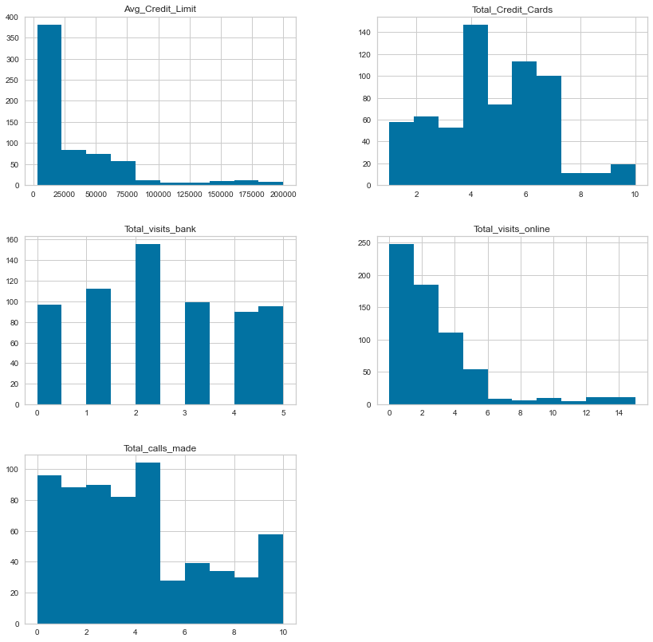

```python
# creating histograms
df.hist(figsize=(14, 14))
plt.show()
```

#### Analyzing the count and percentage of attributes using a bar chart

```
Unique values in Avg_Credit_Limit are :
8000     32
6000     30
13000    28
9000     27
19000    26
10000    25
11000    24
7000     24
14000    23
17000    23
16000    22
18000    22
5000     20
20000    20
15000    17
Name: Avg_Credit_Limit, dtype: int64
Only displaying first 15 of 110 values.
```

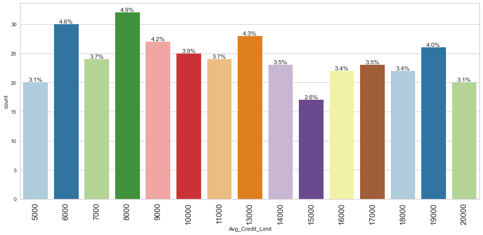

```
--------------------------------------------------

Unique values in Total_Credit_Cards are :
4     147
6     113
7     100
5      74
2      63
1      58
3      53
10     19
9      11
8      11
Name: Total_Credit_Cards, dtype: int64
```

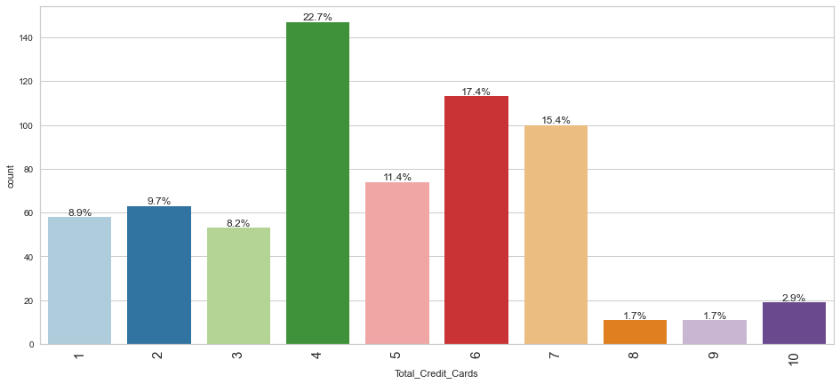

```
--------------------------------------------------

Unique values in Total_visits_bank are :
2    156
1    112
3     99
0     97
5     95
4     90
Name: Total_visits_bank, dtype: int64
```

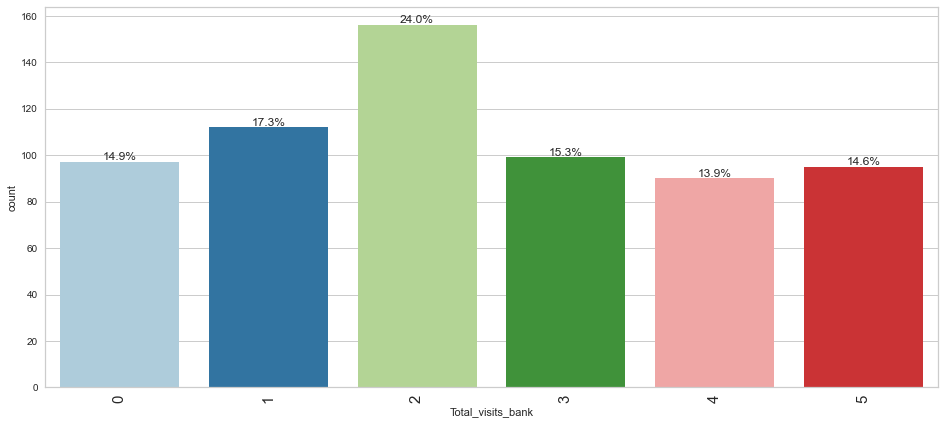

```
--------------------------------------------------

Unique values in Total_visits_online are :
2     185
0     141
1     107
4      68
5      54
3      43
15     10
7       7
10      6
12      6
8       6
11      5
13      5
9       4
14      1
Name: Total_visits_online, dtype: int64
Only displaying first 15 of 16 values.
```

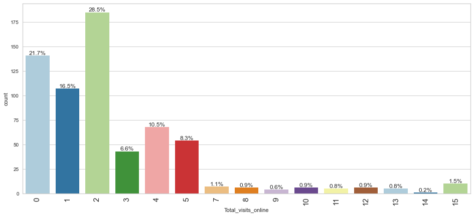

```
--------------------------------------------------

Unique values in Total_calls_made are :
4     104
0      96
2      90
1      88
3      82
6      39
7      34
9      32
8      30
5      28
10     26
Name: Total_calls_made, dtype: int64
```

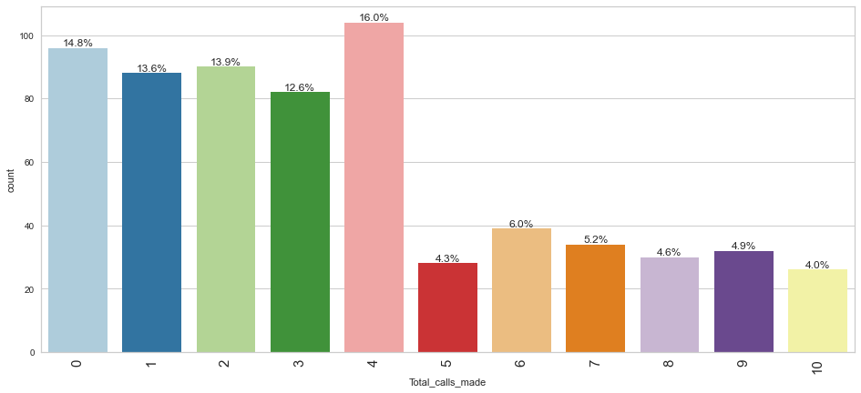

```python
# printing the number of occurrences of each unique value in each categorical column

num_to_display = 15
for column in df:
    val_counts = df[column].value_counts(
        dropna=False
    )  # Kept dropNA to False to see the NA value count as well
    #val_countsP = df[column].value_counts(dropna=False, normalize=True)
    print("Unique values in", column, "are :")
    print(val_counts.iloc[:num_to_display])
    #print(val_countsP.iloc[:num_to_display])
    if len(val_counts) > num_to_display:
        print(f"Only displaying first {num_to_display} of {len(val_counts)} values.")

    labeled_barplot(df, column, perc=True, n=num_to_display);
    plt.tight_layout();

    print("-" * 50)
    print(" ")
```

### Insights from Data

*Click to return to TOC*

**Observations:**

### Univariate Analysis

*Click to return to TOC*

#### Aalyzing the Average Credit limit of the Customers

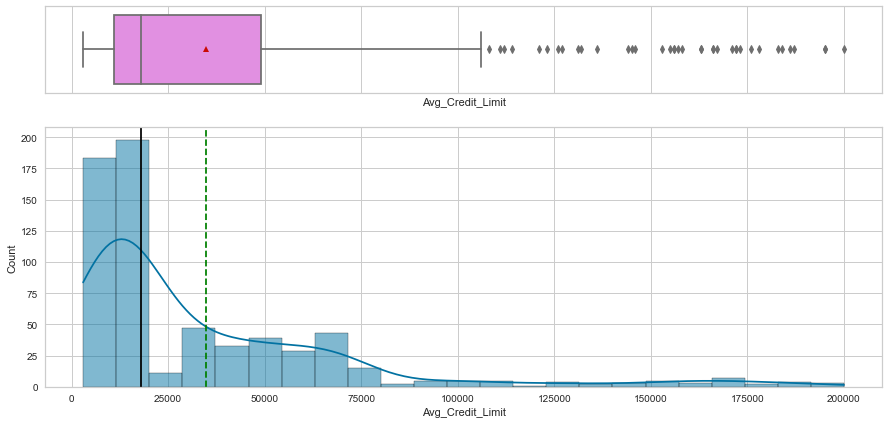

```python
histogram_boxplot(df, "Avg_Credit_Limit")
```

**Observations:**

- Credit Limit has a positive skewed distribution. There are few outliers which needs to be analyzed for treatment
- The Mean & Median are farther from each other and Median is less than the Mean value

```python
# The number of outliers
len(df[(df["Avg_Credit_Limit"] > 100000)])
```

```
39
```

```python
df[df["Avg_Credit_Limit"] > 100000].groupby(["Total_Credit_Cards"])["Avg_Credit_Limit"].mean()
```

```
Total_Credit_Cards
7     168142.857143
8     144300.000000
9     158125.000000
10    152071.428571
Name: Avg_Credit_Limit, dtype: float64
```

- The Customers with the outliers with more than 100K of credit limit seems to be holding multiple number of of credit cards. Hence there is a possibility that the credit limit is high for these customers.We dont need to treat the outliers.
- **We dont need to treat the outliers.**

#### Analyzing the Total number of Credit cards

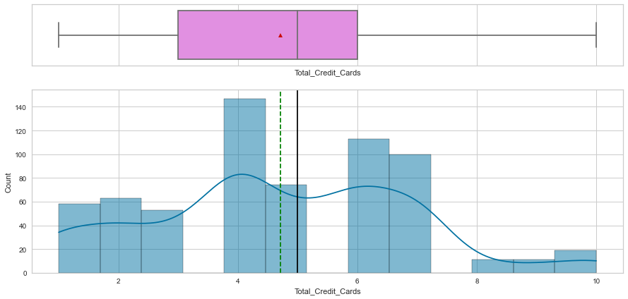

```python
histogram_boxplot(df, "Total_Credit_Cards")
```

**Observations:**

- Mean & Median are almost close to each other
- The distribution is normal with peaks in two places.
- There are no outliers identified for the feature

#### Analyzing the Total Bank visits

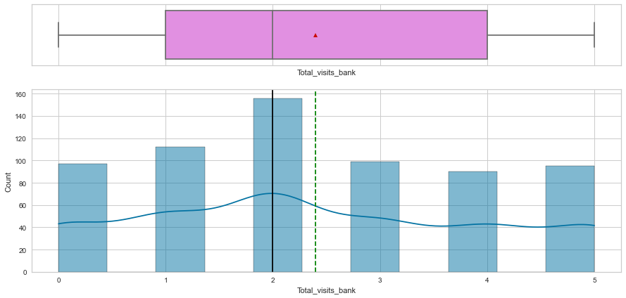

```python
histogram_boxplot(df, "Total_visits_bank")
```

**Observations:**

- Mean & Median are almost close to each other and Median is less than the Mean value
- The distribution is normal
- There are no outliers identified for the feature

#### Analyzing the number of Online visits

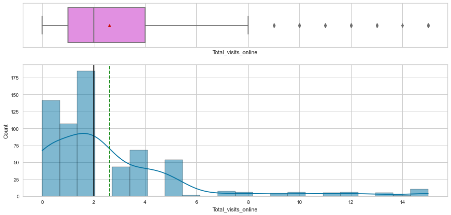

```python
histogram_boxplot(df, "Total_visits_online")
```

**Observations:**

- Mean & Median are almost close to each other and Median is less than the Mean value
- Total visits online has a positive skewed distribution. There are few outliers which needs to be analyzed for treatment

```python
df[df["Total_visits_online"] > 8]
```

|  | Avg_Credit_Limit | Total_Credit_Cards | Total_visits_bank | Total_visits_online | Total_calls_made |
| --- | --- | --- | --- | --- | --- |
| 1 | 50000 | 3 | 0 | 10 | 9 |
| 4 | 100000 | 6 | 0 | 12 | 3 |
| 6 | 100000 | 5 | 0 | 11 | 2 |
| 601 | 157000 | 9 | 1 | 14 | 1 |
| 602 | 94000 | 9 | 1 | 11 | 0 |
| 604 | 131000 | 9 | 1 | 10 | 1 |
| 605 | 96000 | 10 | 1 | 11 | 2 |
| 606 | 136000 | 8 | 0 | 13 | 0 |
| 607 | 121000 | 7 | 0 | 13 | 2 |
| 608 | 158000 | 7 | 0 | 13 | 0 |
| 609 | 108000 | 10 | 0 | 15 | 1 |
| 610 | 166000 | 9 | 1 | 12 | 2 |
| 611 | 176000 | 10 | 1 | 15 | 2 |
| 613 | 178000 | 7 | 0 | 11 | 0 |
| 615 | 156000 | 9 | 1 | 10 | 2 |
| 616 | 146000 | 10 | 0 | 12 | 1 |
| 617 | 84000 | 9 | 1 | 15 | 0 |
| 619 | 200000 | 10 | 0 | 13 | 0 |
| 620 | 195000 | 8 | 0 | 15 | 0 |
| 622 | 163000 | 7 | 1 | 10 | 1 |
| 626 | 173000 | 9 | 1 | 11 | 0 |
| 628 | 184000 | 7 | 1 | 15 | 2 |
| 629 | 123000 | 8 | 1 | 15 | 2 |
| 630 | 144000 | 10 | 0 | 10 | 2 |
| 631 | 97000 | 10 | 1 | 9 | 2 |
| 633 | 127000 | 10 | 1 | 15 | 1 |
| 634 | 171000 | 10 | 0 | 15 | 0 |
| 636 | 183000 | 9 | 0 | 9 | 2 |
| 639 | 195000 | 10 | 1 | 12 | 2 |
| 640 | 132000 | 9 | 1 | 12 | 2 |
| 642 | 95000 | 10 | 0 | 15 | 1 |
| 643 | 172000 | 10 | 1 | 9 | 1 |
| 644 | 99000 | 10 | 1 | 10 | 0 |
| 645 | 84000 | 10 | 1 | 13 | 2 |
| 646 | 145000 | 8 | 1 | 9 | 1 |
| 647 | 172000 | 10 | 1 | 15 | 0 |
| 648 | 167000 | 9 | 0 | 12 | 2 |

- Based on the above data, we see that for the outliers identified have the data for the Total_visits_bank is zero or very minimal when the Total_visits_online is more. Its normal that these customers would have used more online transactions when not visiting the banks

```python
df.groupby(['Total_visits_bank'])[['Total_visits_online']].median()
```

| Total_visits_bank | Total_visits_online |
| --- | --- |
| 0 | 4.0 |
| 1 | 4.0 |
| 2 | 2.0 |
| 3 | 1.0 |
| 4 | 1.0 |
| 5 | 1.0 |

- Based on the above grouping, we could confirm the trend between the visits to the bank vs online. When the visit to the online mode increases, there is very less number of visits to the bank.
- **We dont need to treat the outliers.**

#### Analyzing the number of Service calls made to the bank

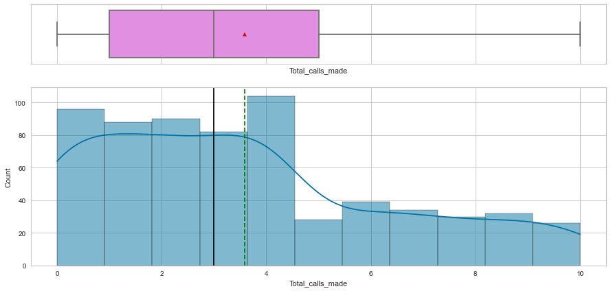

```python
histogram_boxplot(df, "Total_calls_made")
```

**Observations:**

- The Median is less than the Mean
- The distribution has a positive skew pattern with no outliers

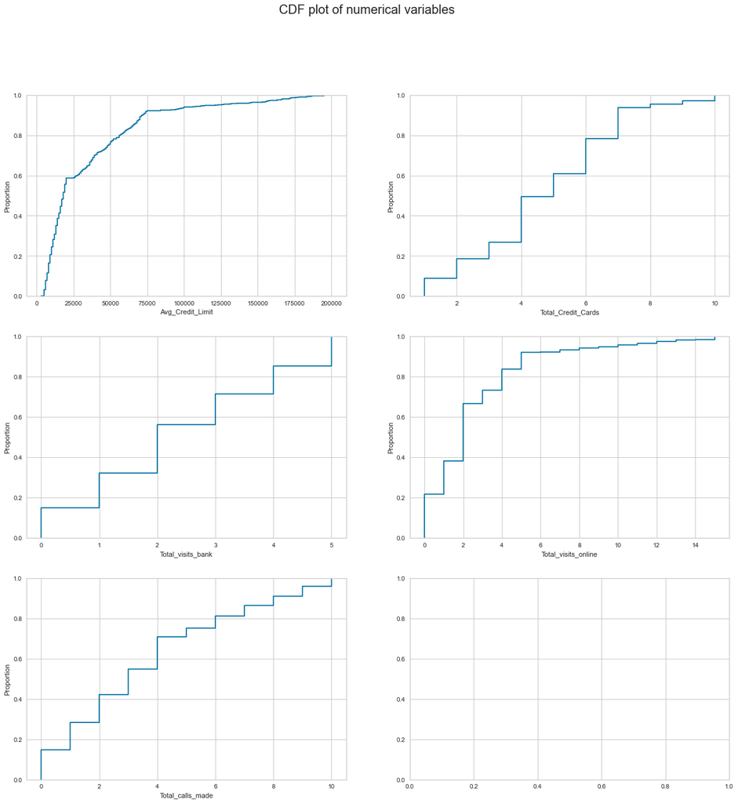

```python
fig, axes = plt.subplots(3, 2, figsize=(20, 20))
fig.suptitle("CDF plot of numerical variables", fontsize=20)
counter = 0
for ii in range(3):
    sns.ecdfplot(ax=axes[ii][0], x=df[num_col[counter]])
    counter = counter + 1
    if counter != 5 :
        sns.ecdfplot(ax=axes[ii][1], x=df[num_col[counter]])
        counter = counter + 1
    else:
        pass
```

**Observations:**

- Almost 90% of the customers have 75K as the credit limit
- Almost 90% of the customers have 7 credit cards
- Almost 80% have visited bank 4 times
- Almost 90% of them have visited online 5 times

### Data Description Post Outlier Validation & treatment

*Click to return to TOC*

```python
df.info()
```

```
<class 'pandas.core.frame.DataFrame'>
RangeIndex: 649 entries, 0 to 648
Data columns (total 5 columns):
 #   Column               Non-Null Count  Dtype
---  ------               --------------  -----
 0   Avg_Credit_Limit     649 non-null    int64
 1   Total_Credit_Cards   649 non-null    int64
 2   Total_visits_bank    649 non-null    int64
 3   Total_visits_online  649 non-null    int64
 4   Total_calls_made     649 non-null    int64
dtypes: int64(5)
memory usage: 25.5 KB
```

```python
# Data Secription of Categorical variables
df.describe().T
```

|  | count | mean | std | min | 25% | 50% | 75% | max |
| --- | --- | --- | --- | --- | --- | --- | --- | --- |
| Avg_Credit_Limit | 649.0 | 34878.274268 | 37813.736638 | 3000.0 | 11000.0 | 18000.0 | 49000.0 | 200000.0 |
| Total_Credit_Cards | 649.0 | 4.708783 | 2.173763 | 1.0 | 3.0 | 5.0 | 6.0 | 10.0 |
| Total_visits_bank | 649.0 | 2.397535 | 1.625148 | 0.0 | 1.0 | 2.0 | 4.0 | 5.0 |
| Total_visits_online | 649.0 | 2.624037 | 2.952888 | 0.0 | 1.0 | 2.0 | 4.0 | 15.0 |
| Total_calls_made | 649.0 | 3.590139 | 2.877911 | 0.0 | 1.0 | 3.0 | 5.0 | 10.0 |

### Bivariate Analysis

*Click to return to TOC*

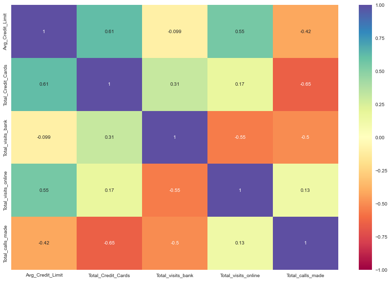

```python
# Plotting Heatmap by creating a 2-D Matrix with correlation plots
correlation = df.corr()
plt.figure(figsize=(15, 10))
sns.heatmap(correlation, vmin=-1, vmax=1, annot=True, cmap="Spectral")
```

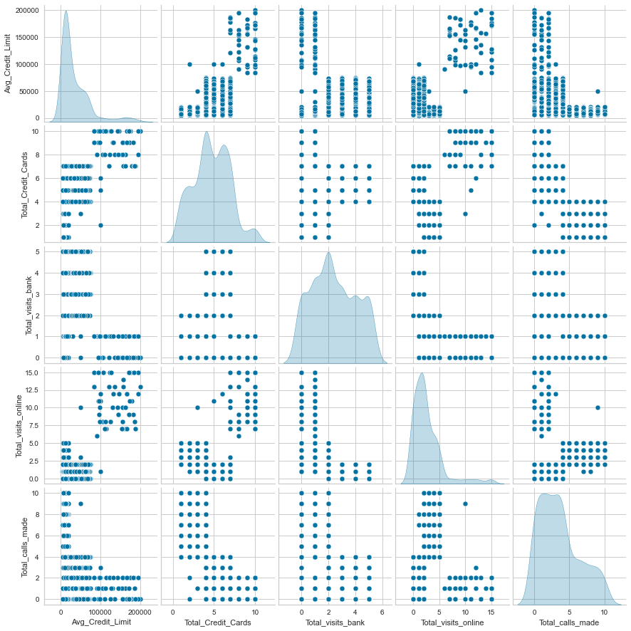

```python
sns.pairplot(data=df, diag_kind="kde")
plt.show()
```

**Observation:**

*Click to return to TOC*

- `Total_Credit_Cards` and `Avg_Credit_Limit` have a high positive correlation which is expected. With increase in number of credit cards the customer is using, the average credit limit increases
- `Total_visits_online` and `Avg_Credit_Limit` have a high correlation. Probably the customers are checking for credit card balance through online system more than visiting the bank. We also see that the `Total_visits_bank` has a negative correlation with the `Avg_Credit_Limit` with customers avoiding to go in person to the bank
- `Total_calls_made` and `Avg_Credit_Limit` has a high negative correlation. With increase in number of credit cards the customer is already using, the calls made by bank decreases. Similarly its having a negative correlation with the `Total_Credit_Cards`. Probably the service to these high card customers are good and there is no additional help required from the bank
- `Total_visits_bank` and `Total_visits_online` have negative correlation, with visits to bank decreases when visits to online system increases
- `Total_visits_bank` and `Total_calls_made` have negative correlation, with more calls being made when the visits to the bank decreases

### Multivariate Analysis - Visualise association with Product Taken & correlation between other Features

*Click to return to TOC*

**`Total_visits_bank` vs `Total_Credit_Cards` vs `Total_visits_online`**

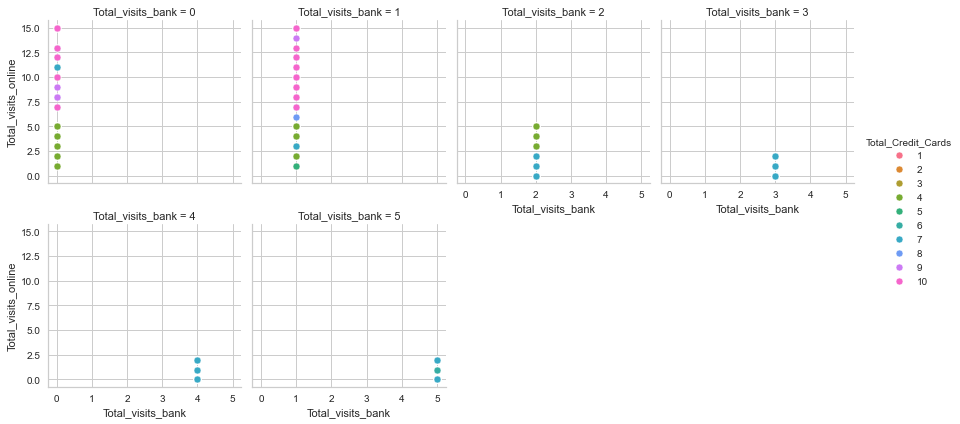

```python
g = sns.FacetGrid(
    df, col="Total_visits_bank", hue="Total_Credit_Cards", col_wrap=4, margin_titles=True
)
g.map(sns.scatterplot, "Total_visits_bank", "Total_visits_online", palette='deep')
g.add_legend()
```

**Observations:**

- We can infer that as the number of visits to the bank increases, the number of online visits gradually decreases
- Customers with more number of cards seem to have more online visits
- Customers with less number of cards seem to have less online visits

**`Avg_Credit_Limit` vs `Total_Credit_Cards` vs `Total_visits_bank`**

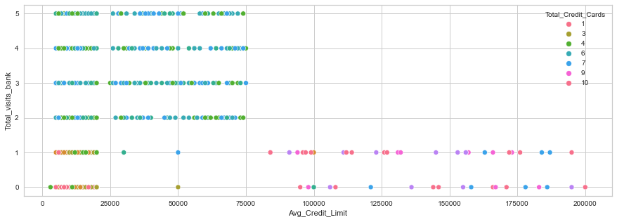

```python
plt.figure(figsize=(15,5))
sns.scatterplot(data=df, x='Avg_Credit_Limit', y='Total_visits_bank', hue='Total_Credit_Cards', palette='husl');
```

**Observations:**

- We can infer that as the average credit limit increases, the number of credit card held by the customer increases
- Customers with less credit limits and with less number of cards, have visited the banks very less times
- Customers with less credit limits but with average number of cards, have visited the banks more number of times
- Customers with more credit limits and with high number of cards, have visited the banks very less times

**`Avg_Credit_Limit` vs `Total_Credit_Cards` vs `Total_visits_online`**

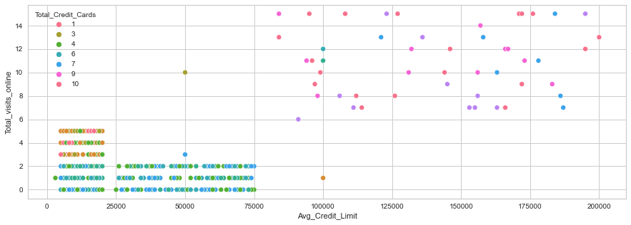

```python
plt.figure(figsize=(15,5))
sns.scatterplot(data=df, x='Avg_Credit_Limit', y='Total_visits_online', hue='Total_Credit_Cards', palette='husl');
```

**Observations:**

**`Total_visits_online` vs `Total_visits_bank` vs `Total_calls_made`**

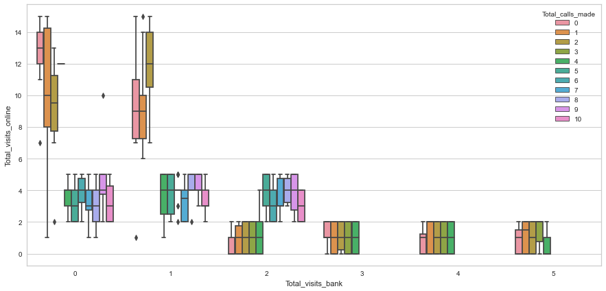

```python
plt.figure(figsize=(15, 7))
sns.boxplot(x="Total_visits_bank", y="Total_visits_online", data=df, hue="Total_calls_made")
plt.show()
```

**Observations:**

## Clustering Techniques

##### *Click to return to TOC*

## Data Preparation for Clustering

*Click to return to TOC*

```python
df.info()
```

```
<class 'pandas.core.frame.DataFrame'>
RangeIndex: 649 entries, 0 to 648
Data columns (total 5 columns):
 #   Column               Non-Null Count  Dtype
---  ------               --------------  -----
 0   Avg_Credit_Limit     649 non-null    int64
 1   Total_Credit_Cards   649 non-null    int64
 2   Total_visits_bank    649 non-null    int64
 3   Total_visits_online  649 non-null    int64
 4   Total_calls_made     649 non-null    int64
dtypes: int64(5)
memory usage: 25.5 KB
```

```python
df.head(10)
```

|  | Avg_Credit_Limit | Total_Credit_Cards | Total_visits_bank | Total_visits_online | Total_calls_made |
| --- | --- | --- | --- | --- | --- |
| 0 | 100000 | 2 | 1 | 1 | 0 |
| 1 | 50000 | 3 | 0 | 10 | 9 |
| 2 | 50000 | 7 | 1 | 3 | 4 |
| 3 | 30000 | 5 | 1 | 1 | 4 |
| 4 | 100000 | 6 | 0 | 12 | 3 |
| 5 | 20000 | 3 | 0 | 1 | 8 |
| 6 | 100000 | 5 | 0 | 11 | 2 |
| 7 | 15000 | 3 | 0 | 1 | 1 |
| 8 | 5000 | 2 | 0 | 2 | 2 |
| 9 | 3000 | 4 | 0 | 1 | 7 |

### Feature Scaling

*Click to return to TOC*

```python
# scaling the dataset before clustering
scaler = StandardScaler()

subset = df.copy()
dfKMeans = df.copy()
```

```python
# Applying StandardScaler
subset_scaled = scaler.fit_transform(subset)
```

```python
# creating a dataframe of the scaled columns
subset_scaled_df = pd.DataFrame(subset_scaled, columns=subset.columns)
subset_scaled_df_orig = subset_scaled_df.copy();
```

```python
subset_scaled_df.info()
```

```
<class 'pandas.core.frame.DataFrame'>
RangeIndex: 649 entries, 0 to 648
Data columns (total 5 columns):
 #   Column               Non-Null Count  Dtype
---  ------               --------------  -----
 0   Avg_Credit_Limit     649 non-null    float64
 1   Total_Credit_Cards   649 non-null    float64
 2   Total_visits_bank    649 non-null    float64
 3   Total_visits_online  649 non-null    float64
 4   Total_calls_made     649 non-null    float64
dtypes: float64(5)
memory usage: 25.5 KB
```

```python
subset_scaled_df.head(10)
```

|  | Avg_Credit_Limit | Total_Credit_Cards | Total_visits_bank | Total_visits_online | Total_calls_made |
| --- | --- | --- | --- | --- | --- |
| 0 | 1.723499 | -1.247087 | -0.860606 | -0.550407 | -1.248443 |
| 1 | 0.400209 | -0.786701 | -1.476410 | 2.499808 | 1.881237 |
| 2 | 0.400209 | 1.054846 | -0.860606 | 0.127419 | 0.142526 |
| 3 | -0.129107 | 0.134072 | -0.860606 | -0.550407 | 0.142526 |
| 4 | 1.723499 | 0.594459 | -1.476410 | 3.177634 | -0.205216 |
| 5 | -0.393766 | -0.786701 | -1.476410 | -0.550407 | 1.533495 |
| 6 | 1.723499 | 0.134072 | -1.476410 | 2.838721 | -0.552958 |
| 7 | -0.526095 | -0.786701 | -1.476410 | -0.550407 | -0.900701 |
| 8 | -0.790753 | -1.247087 | -1.476410 | -0.211494 | -0.552958 |
| 9 | -0.843684 | -0.326314 | -1.476410 | -0.550407 | 1.185753 |

- The feature units are uniformly distributed

## Cluster Analysis - Applying K-means Algorithm

##### *Click to return to TOC*

```
Number of Clusters: 1 	Average Distortion: 2.007896349270688
Number of Clusters: 2 	Average Distortion: 1.4576197022077821
Number of Clusters: 3 	Average Distortion: 1.1434401208195095
Number of Clusters: 4 	Average Distortion: 1.0435538595477063
Number of Clusters: 5 	Average Distortion: 0.9876621009681703
Number of Clusters: 6 	Average Distortion: 0.94031018098628
Number of Clusters: 7 	Average Distortion: 0.9081767500625029
Number of Clusters: 8 	Average Distortion: 0.8878693158146816
```

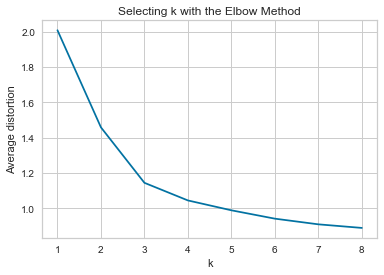

```python
clusters = range(1, 9)
meanDistortions = []

for k in clusters:
    model = KMeans(n_clusters=k)
    model.fit(subset_scaled_df)
    prediction = model.predict(subset_scaled_df)
    distortion = (
        sum(
            np.min(cdist(subset_scaled_df, model.cluster_centers_, "euclidean"), axis=1)
        )
        / subset_scaled_df.shape[0]
    )

    meanDistortions.append(distortion)

    print("Number of Clusters:", k, "\tAverage Distortion:", distortion)

plt.plot(clusters, meanDistortions, "bx-")
plt.xlabel("k")
plt.ylabel("Average distortion")
plt.title("Selecting k with the Elbow Method")
plt.show()
```

**In the above plot, the elbow is seen for K=2, K=3, K=4 & also in K=5.**

```
For n_clusters = 2, the silhouette score is 0.41800025566689647)
For n_clusters = 3, the silhouette score is 0.516281010855363)
For n_clusters = 4, the silhouette score is 0.3570238219413198)
For n_clusters = 5, the silhouette score is 0.2723299188401586)
For n_clusters = 6, the silhouette score is 0.2570813252005605)
For n_clusters = 7, the silhouette score is 0.24960017409628557)
For n_clusters = 8, the silhouette score is 0.22556732935407947)
For n_clusters = 9, the silhouette score is 0.20962372342189262)
```

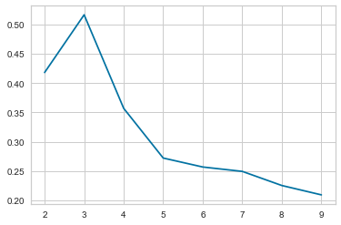

```python
#Checking the silhouette scores
sil_score = []
cluster_list = list(range(2, 10))
for n_clusters in cluster_list:
    clusterer = KMeans(n_clusters=n_clusters)
    preds = clusterer.fit_predict((subset_scaled_df))
    # centers = clusterer.cluster_centers_
    score = silhouette_score(subset_scaled_df, preds)
    sil_score.append(score)
    print("For n_clusters = {}, the silhouette score is {})".format(n_clusters, score))

plt.plot(cluster_list, sil_score)
plt.show()
```

- **From the Silhouette scores, we see that 3 is a good value of K.We will do a deeper investigation for different K values using SilhouetteVisualizer**